# Assignemt

# Assignment - Machine Learning

```r
library("ggplot2")
library("caret")
library("tidyr")
```

## Introduction

The following will investigate the aplicabliity of different algorithm for the classfication of different types of dumbell excecises based on sensorial data collected by a test group carrying out the different excercises.

## Loading Data

The training and test data are loaded from disk. Due to the large number of features, only features of the following kind will be retained: those no containing NA’s and those not consisting of feature variables with large numbers of “blank” values. Furthermore the timestamps, new_window, num_window, user_name and X features will be disregarded (the last one is particularly important to remove, as including it would allow any tree-based algorthim to trivially find a perfect split, with no predicitive power).

Finally the provided training data will be split into training and test data, whereas the provided test data will be considered the validation set. This is necessary, as, in order to asses the degree of overfitting, a test set with known classe variable is necessary (this is not the case for the data in pml-testing.csv).

```r
pmlTrain <- read.csv("pml-training.csv")
pmlValidate <- read.csv("pml-testing.csv")

cols=colSums(is.na(pmlTrain))==0
pmlTrainClean <- pmlTrain[,cols]
pmlValidateClean <- pmlValidate[,cols]
cols=colSums(pmlTrainClean=="")==0
pmlTrainClean <- pmlTrainClean[,cols]
pmlValidateClean <- pmlValidateClean[,cols]
rmCols=c(1,2,3,4,5,6,7)
pmlTrainClean <- pmlTrainClean[,-rmCols]
pmlValidateClean <- pmlValidateClean[,-rmCols]

inTrain = createDataPartition(pmlTrainClean$classe, p = 0.7)[[1]]
training = pmlTrainClean[ inTrain, ]
testing = pmlTrainClean[ -inTrain, ]
```

## Visual Inspection of Data

This preceeding analysis still leaves a large number of features to work with. As an attempt to reduce this we inspect visually how each remaing variable depends on the classe variable.

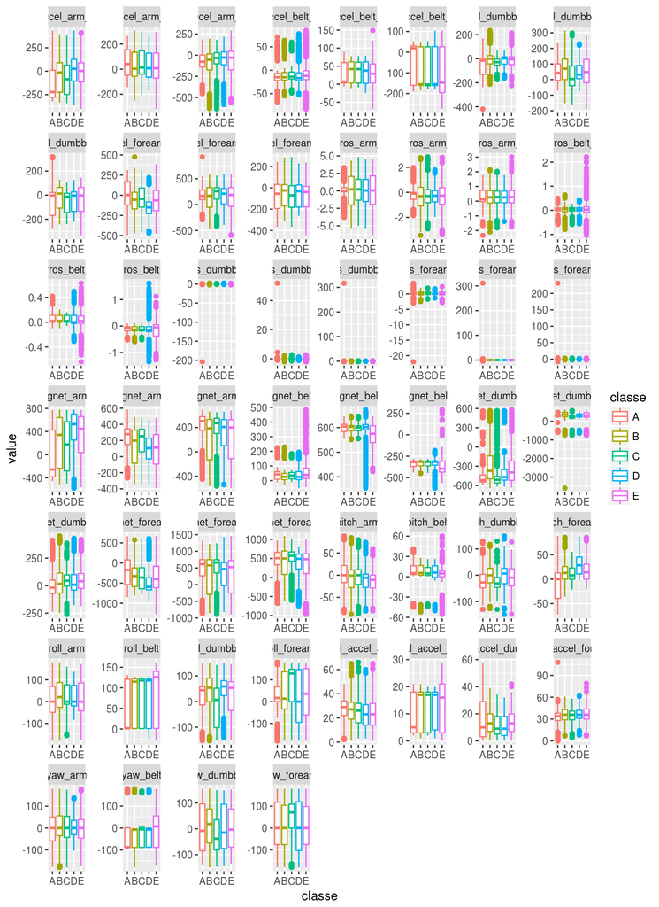

```r
df <- gather(-classe,key="var",value="value",data=training)
p <- ggplot(data=df,aes(x=classe,color=classe,y=value))
p <- p + geom_boxplot()
p <- p + facet_wrap(~ var, scales = "free")
p
```

Evidently there are clear trends separating the classes in different variables, but a small subset of variables allowing for a reduced model is not ovious. Thus the subsequent analysis will proceed with all the features of the previous plot.

## Computing Models

We will begin with a straightforward tree split.

```r
fitRpart <- train(classe ~ .,data=training,method="rpart")
predTrain <- predict(fitRpart, training)
predTest <- predict(fitRpart, testing)
cmTrain <- confusionMatrix(predTrain, training$classe)
cmTest <- confusionMatrix(predTest, testing$classe)
```

Inspection of the confusion matrices (see below) shows an accuracy of around 49% each. This suggests that rpart does significantly better than chance and leads to little overfitting. That being said ~50% leaves room for improvment.

```r
cmTrain
```

```
## Confusion Matrix and Statistics
##
##           Reference
## Prediction    A    B    C    D    E
##          A 3544 1109 1083  987  361
##          B   66  901   73  401  336
##          C  285  648 1240  864  686
##          D    0    0    0    0    0
##          E   11    0    0    0 1142
##
## Overall Statistics
##
##                Accuracy : 0.497
##                  95% CI : (0.4886, 0.5054)
##     No Information Rate : 0.2843
##     P-Value [Acc > NIR] : < 2.2e-16
##
##                   Kappa : 0.343
##  Mcnemar's Test P-Value : NA
##
## Statistics by Class:
##
##                      Class: A Class: B Class: C Class: D Class: E
## Sensitivity            0.9073  0.33898  0.51753   0.0000  0.45228
## Specificity            0.6399  0.92093  0.78106   1.0000  0.99902
## Pos Pred Value         0.5003  0.50703  0.33306      NaN  0.99046
## Neg Pred Value         0.9456  0.85309  0.88456   0.8361  0.89010
## Prevalence             0.2843  0.19349  0.17442   0.1639  0.18381
## Detection Rate         0.2580  0.06559  0.09027   0.0000  0.08313
## Detection Prevalence   0.5157  0.12936  0.27102   0.0000  0.08393
## Balanced Accuracy      0.7736  0.62995  0.64929   0.5000  0.72565
```

```r
cmTest
```

```
## Confusion Matrix and Statistics
##
##           Reference
## Prediction    A    B    C    D    E
##          A 1520  444  502  441  160
##          B   29  401   36  179  159
##          C  122  294  488  344  274
##          D    0    0    0    0    0
##          E    3    0    0    0  489
##
## Overall Statistics
##
##                Accuracy : 0.4924
##                  95% CI : (0.4796, 0.5053)
##     No Information Rate : 0.2845
##     P-Value [Acc > NIR] : < 2.2e-16
##
##                   Kappa : 0.3364
##  Mcnemar's Test P-Value : NA
##
## Statistics by Class:
##
##                      Class: A Class: B Class: C Class: D Class: E
## Sensitivity            0.9080  0.35206  0.47563   0.0000  0.45194
## Specificity            0.6326  0.91509  0.78720   1.0000  0.99938
## Pos Pred Value         0.4956  0.49876  0.32063      NaN  0.99390
## Neg Pred Value         0.9454  0.85475  0.87669   0.8362  0.89004
## Prevalence             0.2845  0.19354  0.17434   0.1638  0.18386
## Detection Rate         0.2583  0.06814  0.08292   0.0000  0.08309
## Detection Prevalence   0.5212  0.13662  0.25862   0.0000  0.08360
## Balanced Accuracy      0.7703  0.63357  0.63142   0.5000  0.72566
```

Next the data is trained with linear discriminant analysis (possbile as all non-continuous features have been removed) as an example of a type of analysis not relying on a tree approach.

```r
fitLda <- train(classe ~ ., data=training, method="lda")
predTrainLda <- predict(fitLda, training)
predTestLda <- predict(fitLda, testing)
cmTrainLda <- confusionMatrix(predTrainLda, training$classe)
cmTestLda <- confusionMatrix(predTestLda, testing$classe)
```

The confusion matrices shown below demonstrate that we have now achieved an accuracy of around 70% in both test and training data. A significant improvment of the application of rpart.

```r
cmTrainLda
```

```
## Confusion Matrix and Statistics
##
##           Reference
## Prediction    A    B    C    D    E
##          A 3195  420  233  131   87
##          B   85 1691  231   85  418
##          C  307  323 1585  263  225
##          D  311   98  284 1683  258
##          E    8  126   63   90 1537
##
## Overall Statistics
##
##                Accuracy : 0.7055
##                  95% CI : (0.6978, 0.7131)
##     No Information Rate : 0.2843
##     P-Value [Acc > NIR] : < 2.2e-16
##
##                   Kappa : 0.6273
##  Mcnemar's Test P-Value : < 2.2e-16
##
## Statistics by Class:
##
##                      Class: A Class: B Class: C Class: D Class: E
## Sensitivity            0.8180   0.6362   0.6615   0.7473   0.6087
## Specificity            0.9114   0.9261   0.9014   0.9172   0.9744
## Pos Pred Value         0.7858   0.6737   0.5864   0.6390   0.8427
## Neg Pred Value         0.9265   0.9139   0.9265   0.9488   0.9171
## Prevalence             0.2843   0.1935   0.1744   0.1639   0.1838
## Detection Rate         0.2326   0.1231   0.1154   0.1225   0.1119
## Detection Prevalence   0.2960   0.1827   0.1968   0.1917   0.1328
## Balanced Accuracy      0.8647   0.7811   0.7815   0.8323   0.7916
```

```r
cmTestLda
```

```
## Confusion Matrix and Statistics
##
##           Reference
## Prediction    A    B    C    D    E
##          A 1382  166  117   56   47
##          B   31  740   96   46  198
##          C  117  136  667  120   92
##          D  133   46  118  698   89
##          E   11   51   28   44  656
##
## Overall Statistics
##
##                Accuracy : 0.704
##                  95% CI : (0.6921, 0.7156)
##     No Information Rate : 0.2845
##     P-Value [Acc > NIR] : < 2.2e-16
##
##                   Kappa : 0.6251
##  Mcnemar's Test P-Value : < 2.2e-16
##
## Statistics by Class:
##
##                      Class: A Class: B Class: C Class: D Class: E
## Sensitivity            0.8256   0.6497   0.6501   0.7241   0.6063
## Specificity            0.9083   0.9218   0.9043   0.9216   0.9721
## Pos Pred Value         0.7817   0.6661   0.5892   0.6439   0.8304
## Neg Pred Value         0.9291   0.9164   0.9245   0.9446   0.9164
## Prevalence             0.2845   0.1935   0.1743   0.1638   0.1839
## Detection Rate         0.2348   0.1257   0.1133   0.1186   0.1115
## Detection Prevalence   0.3004   0.1888   0.1924   0.1842   0.1342
## Balanced Accuracy      0.8670   0.7858   0.7772   0.8228   0.7892
```

```r
set.seed(1234)
fitGbm <- train(classe ~ .,data=training,method="gbm")
predTrain <- predict(fitRpart, training)
predTest <- predict(fitRpart, testing)
cmTrain <- confusionMatrix(predTrain, training$classe)
cmTest <- confusionMatrix(predTest, testing$classe)
```

```r
cmTrain
cmTest
```